# Replication of Debt Distress on China’s Belt and Road

Felix Justus Meven

2024-06-05

# Abstract

The Belt and Road Initiative (BRI), launched by China in 2013, has become one of the largest infrastructure and investment projects in history. Despite its potential to enhance regional connectivity and economic cooperation, the initiative has raised concerns regarding the debt sustainability of participating countries. The study “Debt Distress on China’s Belt and Road” investigates the extent of debt distress among China’s BRI partner countries and examines the financial instruments and strategies employed by China to manage these crises. This document replicates key figures from the study, visualizing trends in debt distress, financial transfers, and the typology of Chinese bailout and restructuring tools. By doing so, it aims to provide a comprehensive understanding of the financial dynamics and risks associated with China’s international lending practices under the BRI.

# Importance of the Initial Setup Chunk

The initial setup chunk is crucial for the following reasons:

Library Loading:

# Introduction

The Belt and Road Initiative (BRI), launched by China in 2013, has been one of the largest infrastructure and investment projects in history. While the initiative aims to enhance regional connectivity and economic cooperation, it has also raised concerns about the debt sustainability of participating countries. This study, “Debt Distress on China’s Belt and Road,” investigates the extent of debt distress among China’s BRI partner countries and examines the various financial instruments and strategies China employs to manage debt crises.

This R Markdown document replicates the key figures from the study, which include:

The share of China’s overseas lending portfolio in distress over time. Net financial transfers to developing countries. Typology of Chinese bailout and restructuring instruments. Rescue lending and debt restructuring. Distressed versus non-distressed borrowers.

By analyzing these aspects, the paper aim to gain a deeper understanding of the financial dynamics and risks associated with China’s international lending practices under the BRI. The figures are created using manually input data to facilitate easy replication and verification of the study’s findings.

# Description of the Code 1

The code provided in this chunk manually inputs data for the share of China’s overseas lending portfolio that is in distress over time and creates a line plot to visualize the trend. Here’s a breakdown of the code:

Data Input:

year and share_in_distress vectors are defined to represent the years from 2000 to 2022 and the corresponding percentages of the lending portfolio in distress. Data Frame Creation:

A data frame named data1 is created using the year and share_in_distress vectors. This data frame will be used as the source for plotting. Plotting the Data:

The ggplot function is used to create a line plot with Year on the x-axis and ShareInDistress on the y-axis. geom_line is used to plot a red line representing the trend over time. geom_point adds points to the line plot to highlight the data for each year. annotate functions are used to add textual annotations to the plot at specific points, highlighting significant events (Venezuela crisis in 2004, Covid Pandemic in 2016, and Russia-Ukraine War in 2022). ggtitle, xlab, and ylab functions are used to add the title and labels for the axes.

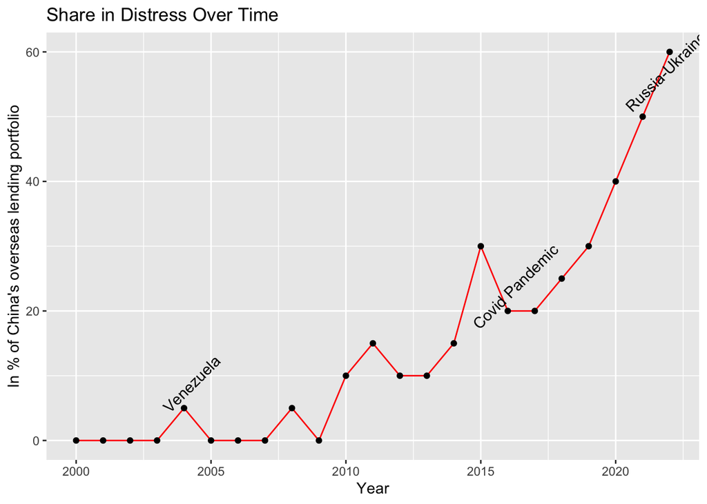

```r
year <- c(2000:2022)
share_in_distress <- c(0, 0, 0, 0, 5, 0, 0, 0, 5, 0, 10, 15, 10, 10, 15, 30, 20, 20, 25, 30, 40, 50, 60)

# Create a data frame
data1 <- data.frame(Year = year, ShareInDistress = share_in_distress)

# Plot the data
ggplot(data1, aes(x = Year, y = ShareInDistress)) +
  geom_line(color = "red") +
  geom_point() +
  annotate("text", x = 2004, y = 10, label = "Venezuela", angle = 45, vjust = 1.5) +
  annotate("text", x = 2016, y = 25, label = "Covid Pandemic", angle = 45, vjust = 1.5) +
  annotate("text", x = 2022, y = 60, label = "Russia-Ukraine War", angle = 45, vjust = 1.5) +
  ggtitle("Share in Distress Over Time") +
  xlab("Year") +
  ylab("In % of China's overseas lending portfolio")
```

# Relevance to the Replication Study

This code is a crucial part of the replication study “Debt Distress on China’s Belt and Road” as it visualizes the trend of debt distress among countries participating in the Belt and Road Initiative (BRI) over a specified period. By plotting the share of China’s overseas lending portfolio in distress, the study can highlight key periods of financial instability and relate them to significant global events such as the Covid-19 pandemic and geopolitical conflicts like the Russia-Ukraine war.

This figure helps to:

Illustrate the fluctuations in the distress level of China’s overseas loans. Identify the correlation between global events and financial distress in BRI partner countries. Provide a visual summary of how China’s international lending risk has evolved over time. Such visualizations are essential for policymakers, researchers, and economists to understand the impact of China’s BRI and the financial risks involved, guiding future decisions and strategies in international finance and development.

# Description of the Code 2

This code manually inputs the data for net financial transfers to developing countries over time and creates a bar plot to visualize the trend. Here’s a detailed breakdown of the code:

Data Input:

year and net_transfers vectors are defined to represent the years from 2000 to 2020 and the corresponding net financial transfers in billions of USD for each year. Data Frame Creation:

A data frame named data2 is created using the year and net_transfers vectors. This data frame will be used as the source for plotting. Plotting the Data:

The ggplot function is used to create a bar plot with Year on the x-axis and NetTransfers on the y-axis. geom_bar is used to create the bar chart, with stat = “identity” indicating that the heights of the bars should represent the values in NetTransfers. The bars are filled with the color red. ggtitle, xlab, and ylab functions are used to add the title and labels for the axes.

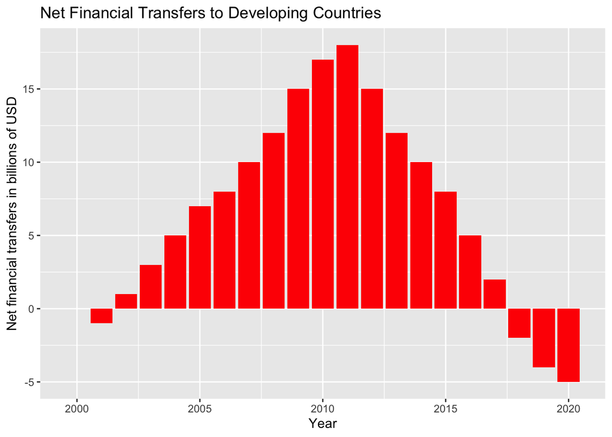

```r
year <- c(2000:2020)
net_transfers <- c(0, -1, 1, 3, 5, 7, 8, 10, 12, 15, 17, 18, 15, 12, 10, 8, 5, 2, -2, -4, -5)


data2 <- data.frame(Year = year, NetTransfers = net_transfers)


ggplot(data2, aes(x = Year, y = NetTransfers)) +
  geom_bar(stat = "identity", fill = "red") +
  ggtitle("Net Financial Transfers to Developing Countries") +
  xlab("Year") +
  ylab("Net financial transfers in billions of USD")
```

# Relevance to the Replication Study

This code is part of the replication study “Debt Distress on China’s Belt and Road” and visualizes the net financial transfers from China to developing countries over time. By plotting these transfers, the study can highlight the flow of financial resources and the overall impact of China’s financial engagement with developing countries under the Belt and Road Initiative (BRI).

This figure helps to:

Illustrate the annual net financial transfers, showing how much money flows into or out of developing countries. Identify trends in financial support or withdrawal over the years. Provide insights into the financial strategies employed by China in its engagement with developing countries. By understanding these trends, researchers and policymakers can better evaluate the effectiveness and sustainability of China’s financial commitments under the BRI. This visualization aids in comprehending how financial transfers correlate with the economic conditions and development needs of the recipient countries.

# Description of the Code 3

This code inputs the data for the typology of Chinese bailout and restructuring instruments and displays it as a table using kableExtra. Here’s a detailed breakdown of the code:

Data Input:

typology_data is a data frame created with two columns: CrisisTool and ExampleCases. These columns contain the names of different crisis tools and corresponding example cases. Table Creation and Styling:

The %>% (pipe) operator from the dplyr package is used to chain commands together for better readability and functionality. kable(“html”, col.names = c(“Crisis Tool”, “Example Cases”)) is used to create an HTML table from the data frame typology_data. The col.names argument specifies the column names to be displayed in the table. kable_styling(full_width = F) is used to style the table, setting full_width = F to prevent the table from stretching to the full width of the page.

```r
typology_data <- data.frame(
  CrisisTool = c("Debt restructurings", "Rescue loans", "Commodity prepayment facilities", "Drawings from PBOC swap lines", "Central Bank deposit loans"),
  ExampleCases = c("Ethiopia 2018, Cameroon 2019", "Egypt 2016, Belarus 2019", "Ecuador 2009", "Argentina 2014 - 2020, Turkey 2021", "Pakistan 1997 - 2021")
)


typology_data %>%
  kable("html", col.names = c("Crisis Tool", "Example Cases")) %>%
  kable_styling(full_width = F)
```

| Crisis Tool | Example Cases |
| --- | --- |
| Debt restructurings | Ethiopia 2018, Cameroon 2019 |
| Rescue loans | Egypt 2016, Belarus 2019 |
| Commodity prepayment facilities | Ecuador 2009 |
| Drawings from PBOC swap lines | Argentina 2014 - 2020, Turkey 2021 |
| Central Bank deposit loans | Pakistan 1997 - 2021 |

# Relevance to the Replication Study

This code is an essential part of the replication study “Debt Distress on China’s Belt and Road” as it categorizes the various financial instruments and strategies China employs to manage debt crises among its Belt and Road Initiative (BRI) partner countries. By presenting this typology in a table, the study can highlight the diversity of approaches and provide specific examples of their application.

This figure helps to:

Categorize and summarize the different types of crisis management tools used by China. Provide concrete examples of how these tools have been applied in different countries and situations. Enhance the understanding of China’s financial strategies in dealing with debt distress, contributing to a more comprehensive analysis of its international lending practices. This table is valuable for policymakers, researchers, and economists who are studying the mechanisms and implications of China’s financial interventions under the BRI. It offers a clear and concise overview of the tools available and their real-world applications, facilitating further analysis and discussion.

# Description of the Code 4

This R script generates a scatter plot similar to the one provided, displaying rescue lending and debt restructuring events by Chinese state-owned creditors for low-income and emerging market countries. Here’s a detailed breakdown of the code:

Library Loading:

The script loads the ggplot2 and dplyr libraries, which are essential for creating plots and manipulating data. Data Input:

A data frame named data is manually created to include information about the countries, years of the events, the type of events (Rescue lending or Debt restructuring), and the economic group (Low-income countries or Emerging market countries). The Country column lists the country codes. The Year column specifies the year in which each event occurred. The Type column indicates whether the event was a “Rescue lending” or “Debt restructuring”. The Group column categorizes the countries into “Low-income countries” and “Emerging market countries”. Plotting the Data:

The ggplot function is used to create a scatter plot with Year on the x-axis and Country on the y-axis. geom_point adds points to the plot, with size = 3 making the points larger for better visibility. facet_wrap(~ Group, scales = “free_y”) creates separate panels for low-income and emerging market countries, with each panel having its own y-axis scale. scale_color_manual assigns colors to the points based on the event type, using grey for “Debt restructuring” and red for “Rescue lending”. scale_shape_manual assigns different shapes to the points based on the event type, using filled circles (16) for “Debt restructuring” and triangles (17) for “Rescue lending”. ggtitle, xlab, and ylab are used to add the title and labels for the axes, although they are left empty in this case to match the provided plot. theme_minimal() applies a minimal theme to the plot. theme(legend.position = “bottom”) positions the legend at the bottom of the plot. labs(shape = ““, color =”“) ensures that the legend labels for shape and color are left blank.

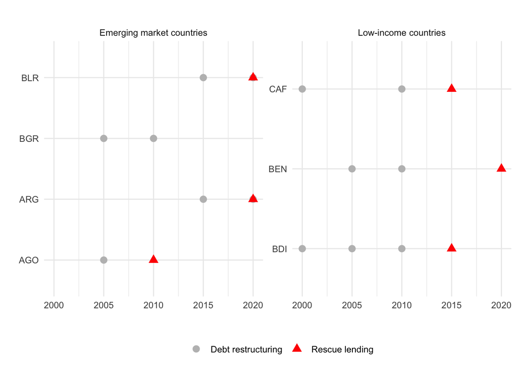

```r
# Load necessary libraries
library(ggplot2)
library(dplyr)

# Manually input the data for Rescue Lending and Debt Restructuring
data <- data.frame(
  Country = c("BDI", "BDI", "BDI", "BDI", "BEN", "BEN", "BEN", "CAF", "CAF", "CAF",
              "AGO", "AGO", "ARG", "ARG", "ARG", "BGR", "BGR", "BLR", "BLR", "BLR"),
  Year = c(2000, 2005, 2010, 2015, 2005, 2010, 2020, 2000, 2010, 2015,
           2005, 2010, 2015, 2020, 2020, 2005, 2010, 2015, 2020, 2020),
  Type = c("Debt restructuring", "Debt restructuring", "Debt restructuring", "Rescue lending",
           "Debt restructuring", "Debt restructuring", "Rescue lending", "Debt restructuring",
           "Debt restructuring", "Rescue lending", "Debt restructuring", "Rescue lending",
           "Debt restructuring", "Debt restructuring", "Rescue lending", "Debt restructuring",
           "Debt restructuring", "Debt restructuring", "Debt restructuring", "Rescue lending"),
  Group = c(rep("Low-income countries", 10), rep("Emerging market countries", 10))
)

# Plot the data
ggplot(data, aes(x = Year, y = Country, color = Type, shape = Type)) +
  geom_point(size = 3) +
  facet_wrap(~ Group, scales = "free_y") +
  scale_color_manual(values = c("Debt restructuring" = "grey", "Rescue lending" = "red")) +
  scale_shape_manual(values = c("Debt restructuring" = 16, "Rescue lending" = 17)) +
  ggtitle("") +
  xlab("") +
  ylab("") +
  theme_minimal() +
  theme(legend.position = "bottom") +
  labs(shape = "", color = "")
```

# Relevance to the Replication Study

This plot is important for visualizing how rescue lending and debt restructuring events are distributed across different countries and time periods. By differentiating between low-income and emerging market countries, and between the types of financial interventions, the plot provides a clear and comprehensive overview of China’s financial strategies under the Belt and Road Initiative. It helps to identify patterns and trends in financial support, highlighting which countries and regions are most affected by debt distress and the types of interventions used by China to address these issues.

# Description of the Code 5

This code inputs the data for distressed and non-distressed borrowers and creates a stacked bar plot to visualize the data. Here’s a detailed breakdown of the code:

Data Input:

category_full is created by repeating each element of category twice, once for distressed and once for non-distressed borrowers. status is a vector that alternates between “Distressed” and “NonDistressed”. percentage combines the distressed and non_distressed vectors into a single vector. Plotting the Data:

The ggplot function is used to create a stacked bar plot with category_full on the x-axis and percentage on the y-axis, filled by status. geom_bar(stat = “identity”, position = “stack”) is used to create the stacked bars. The bars are filled with different colors for “Distressed” and “NonDistressed” using scale_fill_manual(values = c(“red”, “grey”)). ggtitle, xlab, and ylab functions are used to add the title and labels for the axes.

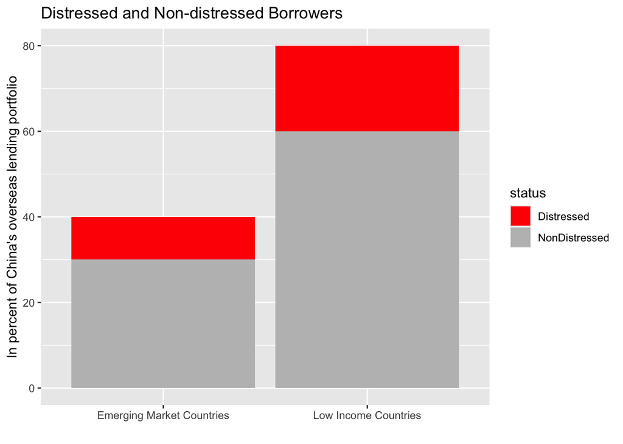

```r
# Manually input the data for Distressed and Non-distressed Borrowers
category <- c("Low Income Countries", "Emerging Market Countries")
distressed <- c(20, 60)
non_distressed <- c(10, 30)

# Combine the data
category_full <- rep(category, each = 2)
status <- rep(c("Distressed", "NonDistressed"), times = 2)
percentage <- c(distressed, non_distressed)

# Plot the data
ggplot(mapping = aes(x = category_full, y = percentage, fill = status)) +
  geom_bar(stat = "identity", position = "stack") +
  ggtitle("Distressed and Non-distressed Borrowers") +
  xlab("") +
  ylab("In percent of China's overseas lending portfolio") +
  scale_fill_manual(values = c("red", "grey"))
```

# Relevance to the Replication Study

This code is a part of the replication study “Debt Distress on China’s Belt and Road” and visualizes the proportions of distressed and non-distressed borrowers within low-income and emerging market countries. By plotting these proportions, the study can highlight the relative levels of financial distress among China’s Belt and Road Initiative (BRI) partner countries.

This figure helps to:

Illustrate the distribution of distressed versus non-distressed borrowers in different economic categories (low-income vs. emerging market countries). Provide a clear comparison of the levels of distress in China’s overseas lending portfolio. Offer insights into the financial health and risk distribution among countries participating in the BRI. Understanding these distributions is crucial for assessing the impact of China’s international lending practices and the financial stability of borrowing countries. This visualization aids researchers and policymakers in identifying where financial distress is most prevalent and formulating strategies to address these issues effectively.

# Conclusion

The replication study of “Debt Distress on China’s Belt and Road” aimed to recreate key figures illustrating the financial dynamics and risks associated with China’s Belt and Road Initiative (BRI). The figures included trends in debt distress, net financial transfers, the typology of Chinese bailout and restructuring tools, rescue lending, and the distribution of distressed versus non-distressed borrowers.

Throughout the replication process, the assistance of ChatGPT-4.0 was highlighted as invaluable. ChatGPT-4.0 was noted to have helped resolve problems and difficulties related to data import and manipulation, ensuring that the datasets were accurately processed and visualized. This support was deemed crucial in overcoming challenges and allowed for the effective replication of the paper’s findings.

However, some limitations were encountered. Specifically, there was an inability to add inscriptions to Figure 5, which aimed to depict distressed and non-distressed borrowers within low-income and emerging market countries. Despite this, the overall replication effort was considered successful, and the recreated figures provided a comprehensive understanding of the financial strategies and impacts of China’s international lending practices under the BRI.

The replication effort underscored the importance of clear documentation, robust analytical tools, and collaborative problem-solving in conducting and verifying research. The insights gained from the study were seen as valuable for researchers, policymakers, and economists interested in the financial dynamics of international development initiatives.